# Bulk RNA-Seq Analysis

Dulce Ma. Montero Rasgado

2023-07-12

# Bulk RNA-Seq Analysis

## Dulce María Montero Rasgado

```
## Setting options('download.file.method.GEOquery'='auto')
```

```
## Setting options('GEOquery.inmemory.gpl'=FALSE)
```

```r
rse_brain <- readRDS("rse_brain.RDS")
rse_colon <- readRDS("rse_colon.RDS")
rse_liver <- readRDS("rse_liver.RDS")

# access to count of reads tables
assays(rse_brain)$counts <- transform_counts(rse_brain)
assays(rse_colon)$counts <- transform_counts(rse_colon)
assays(rse_liver)$counts <- transform_counts(rse_liver)
```

## 1. Filtering and cleaning of the data sets

After checking and selecting the three replicates of each tissue we have:  
**Brain replicates:** 11, 12, 13  
**Colon replicates:** 11, 20, 21  
**liver replicates:** 11, 20, 21

# extracting a table with the replicates of each tissue

```r
rse_brain_selected <- rse_brain[,c(11, 12, 13)]
rse_colon_selected <- rse_colon[,c(11, 20, 21)]
rse_liver_selected <- rse_liver[,c(11, 20, 21)]

counts_brain_selected <- assays(rse_brain_selected)$counts
counts_colon_selected <- assays(rse_colon_selected)$counts
counts_liver_selected <- assays(rse_liver_selected)$counts
```

Building the count table, give more meaningful name to the columns and the rows, and building the DGE object for edgeR.

```r
x <- cbind(counts_brain_selected,counts_colon_selected,counts_liver_selected)

colnames(x) <- c("Brain11", "Brain12","Brain13",
                 "Colon11", "Colon20","Colon21",
                 "liver11", "liver20","liver21")

rownames(x) <- rowData(rse_brain_selected)$gene_name

y <- DGEList(counts=x)
```

Defying how replicates are grouped:

```r
group <- as.factor(c("Brain","Brain","Brain",
                     "Colon","Colon","Colon",
                     "liver","liver","liver"))

y$samples$group <- group
```

We add to the samples info the “quality” information that we employed to select them. For this we can add new labels to the “samples” field of the DGE object, like we just did for the groups

```r
y$samples$rin <- as.factor(c(colData(rse_brain_selected)$gtex.smrin,
                             colData(rse_colon_selected)$gtex.smrin,
                             colData(rse_liver_selected)$gtex.smrin))

y$samples$slice <- as.factor(c(colData(rse_brain_selected)$gtex.smtsd,
                               colData(rse_colon_selected)$gtex.smtsd,
                               colData(rse_liver_selected)$gtex.smtsd))

y$samples$sex <- as.factor(c(colData(rse_brain_selected)$gtex.sex,
                             colData(rse_colon_selected)$gtex.sex,
                             colData(rse_liver_selected)$gtex.sex))

y$samples$age <- as.factor(c(colData(rse_brain_selected)$gtex.age,
                             colData(rse_colon_selected)$gtex.age,
                             colData(rse_liver_selected)$gtex.age))

y$samples$rRNA <- as.factor(c(colData(rse_brain_selected)$gtex.smrrnart,
                              colData(rse_colon_selected)$gtex.smrrnart,
                              colData(rse_liver_selected)$gtex.smrrnart))

y$samples$mapped <- as.factor(c(colData(rse_brain_selected)$"recount_qc.star.uniquely_mapped_reads_%_both",
                                colData(rse_colon_selected)$"recount_qc.star.uniquely_mapped_reads_%_both",
                                colData(rse_liver_selected)$"recount_qc.star.uniquely_mapped_reads_%_both"))

y$samples$chrm <- as.factor(c(colData(rse_brain_selected)$"recount_qc.aligned_reads%.chrm",
                              colData(rse_colon_selected)$"recount_qc.aligned_reads%.chrm",
                              colData(rse_liver_selected)$"recount_qc.aligned_reads%.chrm"))
y
```

```
## An object of class "DGEList"
## $counts
##              Brain11 Brain12 Brain13 Colon11 Colon20 Colon21 liver11 liver20
## SNX18P15           0       0       0       0       0       0       0       0
## SNX18P16           0       0       0       0       0       0       0       0
## ANKRD20A12P        0       0       0       0       0       0       0       0
## ANKRD20A15P        0       0       0       0       0       0       0       0
## LOC105379272       0       0       0       0       0       0       0       0
##              liver21
## SNX18P15           0
## SNX18P16           0
## ANKRD20A12P        0
## ANKRD20A15P        0
## LOC105379272       0
## 54037 more rows ...
##
## $samples
##         group lib.size norm.factors rin
## Brain11 Brain 25327468            1 6.4
## Brain12 Brain 32538624            1 7.5
## Brain13 Brain 29674279            1 7.1
## Colon11 Colon 29396396            1   8
## Colon20 Colon 28682271            1   6
## Colon21 Colon 26284881            1 7.6
## liver11 liver 30763889            1 8.2
## liver20 liver 33338193            1 6.2
## liver21 liver 32331391            1 7.8
##                                            slice sex   age       rRNA mapped
## Brain11 Brain - Anterior cingulate cortex (BA24)   1 60-69  0.0654561     89
## Brain12       Brain - Spinal cord (cervical c-1)   1 60-69  0.0152067   91.3
## Brain13                 Brain - Substantia nigra   1 50-59  0.0527296   89.8
## Colon11                       Colon - Transverse   1 40-49 0.00681986   87.3
## Colon20                       Colon - Transverse   1 20-29 0.00761945   90.7
## Colon21                       Colon - Transverse   1 30-39 0.00996025   91.7
## liver11                                    Liver   2 40-49 0.00923495   89.1
## liver20                                    Liver   2 50-59  0.0176652   88.9
## liver21                                    Liver   1 50-59 0.00663764   86.6
##          chrm
## Brain11 28.16
## Brain12  7.62
## Brain13 19.75
## Colon11 13.53
## Colon20 16.95
## Colon21 20.83
## liver11 10.67
## liver20   7.4
## liver21 10.82
```

lib-sizes are fine :D

```r
table(rowSums(y$counts==0)==9)
```

```
##
## FALSE  TRUE
## 39690 14352
```

Filtrado de y en función de: - Su expresión (utilizando el grupo definido)

```r
keep.exprs <- filterByExpr(y, group=group)
  y <- y[keep.exprs,, keep.lib.sizes=FALSE]
  dim(y)
```

```
## [1] 23841     9
```

> Hay 23841 genes que cumplen con los criterios de expresión definidos y están presentes en al menos uno de los replicados de los tejidos cerebro, colon y hígado. Se están considerando 23841 genes para el análisis, lo que permite estudiar su expresión y comprender cómo se relaciona con los diferentes tejidos y condiciones experimentales. Al centrarse en estos genes específicos, se reduce el ruido o la variabilidad no deseada en el análisis y se puede obtener una visión más precisa de los patrones de expresión génica asociados con los tejidos estudiados.

## Transforming counts | Normalization

Aim: visualize the normalization effects on the logCPM

```r
logcpm_before <- cpm(y, log=TRUE)
y <- calcNormFactors(y, method = "TMM") #add norm counts
print(y$samples)
```

```
##         group lib.size norm.factors rin
## Brain11 Brain 25265530    1.0052863 6.4
## Brain12 Brain 32496629    0.9512818 7.5
## Brain13 Brain 29624232    1.1003227 7.1
## Colon11 Colon 29358237    1.3180757   8
## Colon20 Colon 28644509    1.3348110   6
## Colon21 Colon 26251574    1.3738811 7.6
## liver11 liver 30738913    0.7116838 8.2
## liver20 liver 33305873    0.9022838 6.2
## liver21 liver 32307803    0.6122679 7.8
##                                            slice sex   age       rRNA mapped
## Brain11 Brain - Anterior cingulate cortex (BA24)   1 60-69  0.0654561     89
## Brain12       Brain - Spinal cord (cervical c-1)   1 60-69  0.0152067   91.3
## Brain13                 Brain - Substantia nigra   1 50-59  0.0527296   89.8
## Colon11                       Colon - Transverse   1 40-49 0.00681986   87.3
## Colon20                       Colon - Transverse   1 20-29 0.00761945   90.7
## Colon21                       Colon - Transverse   1 30-39 0.00996025   91.7
## liver11                                    Liver   2 40-49 0.00923495   89.1
## liver20                                    Liver   2 50-59  0.0176652   88.9
## liver21                                    Liver   1 50-59 0.00663764   86.6
##          chrm
## Brain11 28.16
## Brain12  7.62
## Brain13 19.75
## Colon11 13.53
## Colon20 16.95
## Colon21 20.83
## liver11 10.67
## liver20   7.4
## liver21 10.82
```

> Este código realiza una transformación logarítmica de los CPM originales y luego calcula los factores de normalización utilizando el método TMM para ajustar las diferencias en la abundancia de lecturas entre las muestras.

**Comparing count values distributions before and after normalization**

```r
logcpm_after <- cpm(y, log=TRUE)
```

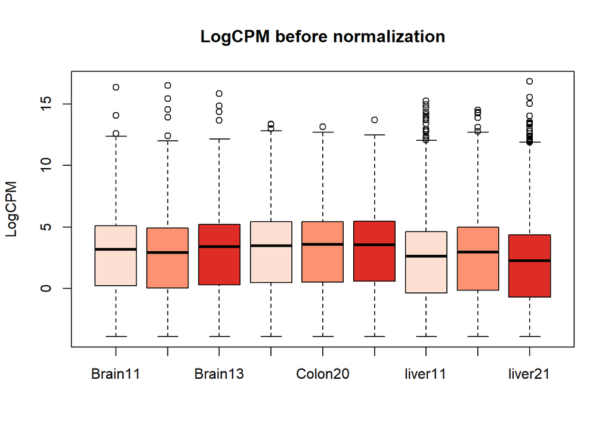

```r
library(RColorBrewer)

# plotting
#boxplot(logcpm_before)
boxplot(logcpm_before, col = brewer.pal(3, "Reds"), outline = TRUE, main = "LogCPM before normalization", ylab = 'LogCPM')
```

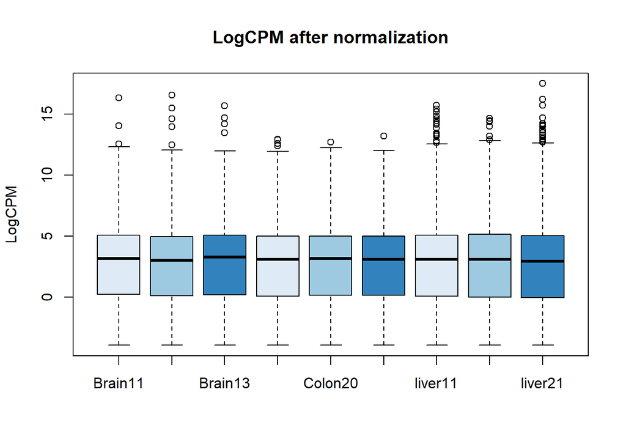

```r
boxplot(logcpm_after, col = brewer.pal(3, "Blues"), outline = TRUE, main = "LogCPM after normalization", ylab = 'LogCPM')
```

“When the normalization factor is > 1, the corresponding box is shifted down viceversa if < 1 seems to be shifted up”

## Linear Model Design

```r
design <- model.matrix(~0+group, data=y$samples)
colnames(design) <- levels(y$samples$group)
design
```

```
##         Brain Colon liver
## Brain11     1     0     0
## Brain12     1     0     0
## Brain13     1     0     0
## Colon11     0     1     0
## Colon20     0     1     0
## Colon21     0     1     0
## liver11     0     0     1
## liver20     0     0     1
## liver21     0     0     1
## attr(,"assign")
## [1] 1 1 1
## attr(,"contrasts")
## attr(,"contrasts")$group
## [1] "contr.treatment"
```

Seeing if and how the samples/replicates cluster together

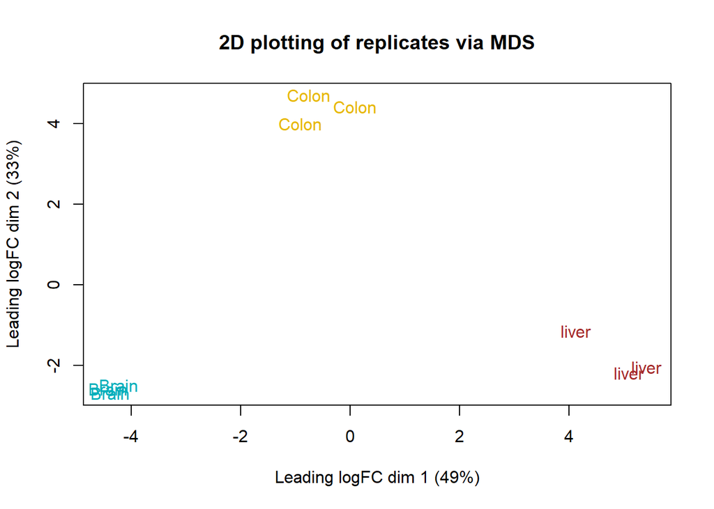

```r
logcpm <- cpm(y, log=TRUE) # calculate the logval of CPM for each gen
plotMDS(logcpm, labels=group, main="2D plotting of replicates via MDS",col = c("#00AFBB","#00AFBB","#00AFBB", "#E7B800","#E7B800","#E7B800",
                "brown","brown","brown"))
```

```r
#grafico de escalamiento multidimensional basado en logcpm
```

Brain clusters fine  
Colon clusters regularly  
There is a liver sample that it is a bit distant from the other two!

> El gráfico MDS proporciona una representación visual de las similitudes o diferencias entre las muestras y cómo se agrupan en función de la variable group.

Now let’s label the points with different info to single out what seem to be the most relevant factors.

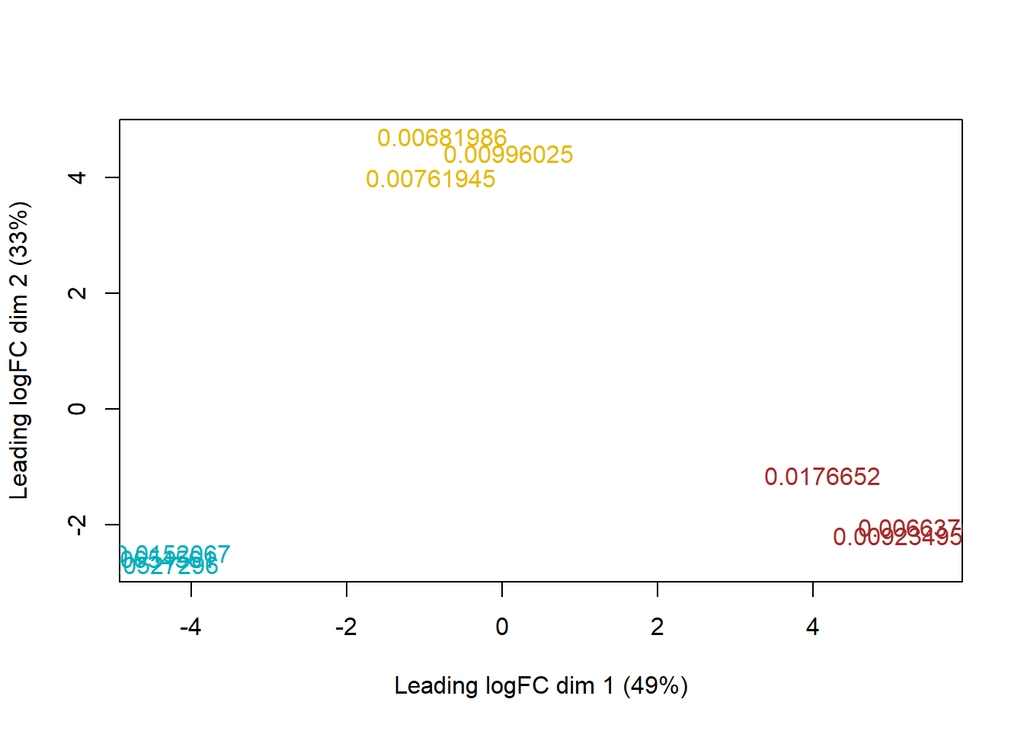

```r
# esto solo cambia el level en funcion de rRNA y chrm
plotMDS(logcpm, labels=y$samples$rRNA,col = c("#00AFBB","#00AFBB","#00AFBB",
                                              "#E7B800","#E7B800","#E7B800",
                                              "brown","brown","brown"))
```

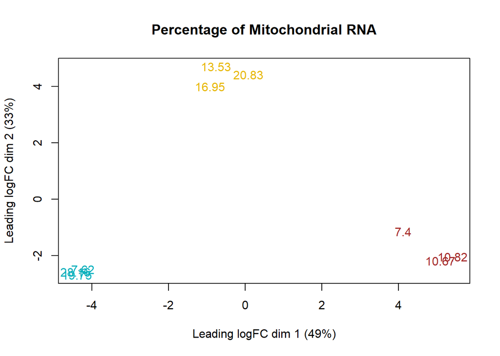

```r
plotMDS(logcpm, labels=y$samples$chrm, main="Percentage of Mitochondrial RNA",col =c("#00AFBB","#00AFBB","#00AFBB",
                                                                                     "#E7B800","#E7B800","#E7B800",
                                                                                     "brown","brown","brown"))
```

Okay the reason is the % of rRNA and mitochondrial RNA, that liver sample differs in 3 units.  
Colon samples differ also more or less 3 units among the three.

# Dispersion estimation

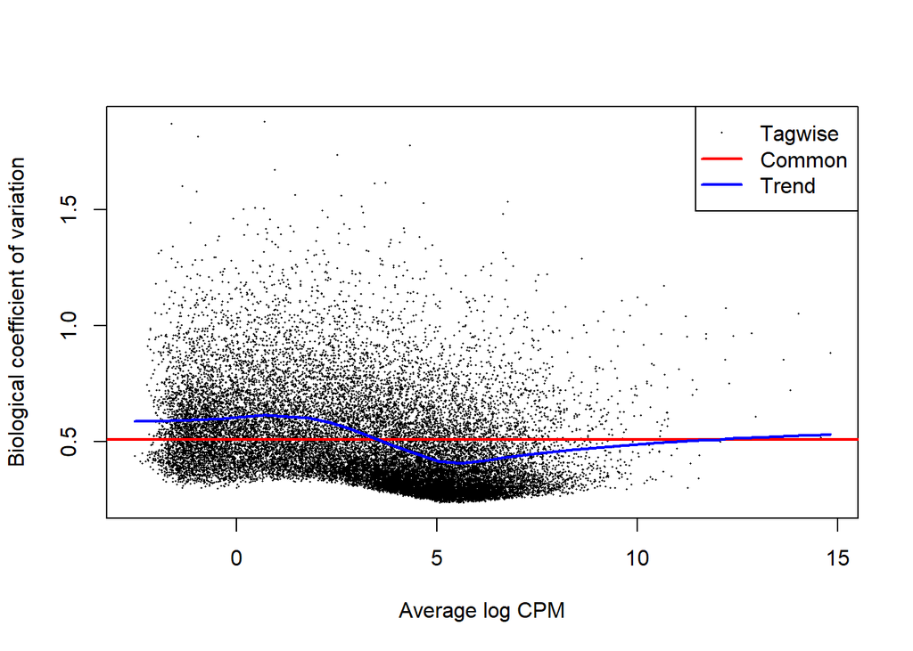

```r
y <- estimateDisp(y, design)
# Biological Coefficient of Variation plot
plotBCV(y)
```

# Fitting the generalized linear model

```r
fit <- glmQLFit(y, design)
```

## Pairwise contrast

```r
# brain     | brain
# muscle    | colon
# spleen    | liver

#colon (top) vs brain (bottom)
qlfCB <- glmQLFTest(fit, contrast=c(-1,1,0))

#liver (top) vs brain (bottom)
qlfLB <- glmQLFTest(fit, contrast=c(-1,0,1))

#liver (top) vs colon (bottom)
qlfLC <- glmQLFTest(fit, contrast=c(0,-1,1))
```

```r
resultsCB <- topTags(qlfCB, n = 10000000, adjust.method = "BH", sort.by = "PValue", p.value = 1)$table


resultsLB <- topTags(qlfLB, n = 10000000, adjust.method = "BH", sort.by = "PValue", p.value = 1)$table

resultsLC <- topTags(qlfLC, n = 10000000, adjust.method = "BH", sort.by = "PValue", p.value = 1)$table
```

### Extracting DE genes

Filter results so that: * Remove genes with low expression values * Remove genes with have little or no annotation + Those whose gene symbol starts with “LOC…” + Those whose gene symbol starts with “LINC…” + Those that correspond to know “short” RNA genes, names starting with “MIR…” and “SNORD…” + Those that correspond to ribosomal proteins (gene symbol starts with “RPL….”)

```r
filterResult <- function(x) {
    x <- x[x$logCPM > 0 & x$FDR <= 0.01, ]
    x <- x[!(grepl("^LOC|^LINC|^MIR|^SNORD|^RPL", rownames(x))), ]
    return(x)
}
```

```r
filterCB <- filterResult(resultsCB)
filterLB <- filterResult(resultsLB)
filterLC <- filterResult(resultsLC)
```

```r
up <- list(
     # BRAIN
     BC = length(rownames(filterCB)[filterCB$logFC < 0]),
     BL = length(rownames(filterLB)[filterLB$logFC < 0]),
     BvALL = length(intersect(rownames(filterCB)[filterCB$logFC < 0],
                              rownames(filterLB)[filterLB$logFC < 0])),
     # COLON
     CB = length(rownames(filterCB)[filterLC$logFC > 0] ), #FIXXXX
     CL = length(rownames(filterLC)[filterCB$logFC < 0 ]),
     CvALL = length(intersect(rownames(filterLC)[filterLC$logFC > 0],
                              rownames(filterCB)[filterCB$logFC < 0])),

     # LIVER
     LB = length(rownames(filterLB)[filterLC$logFC > 0] ),
     LC = length(rownames(filterLC)[filterLB$logFC > 0] ),
     LvALL = length(intersect(rownames(filterLC)[filterLC$logFC > 0],
                              rownames(filterLB)[filterLB$logFC > 0]))

)


down <- list(
     # BRAIN
     BC = length(rownames(filterCB)[filterCB$logFC > 0]),
     BL = length(rownames(filterLB)[filterLB$logFC > 0]),
     BvALL = length(intersect(rownames(filterCB)[filterCB$logFC > 0],
                              rownames(filterLB)[filterLB$logFC > 0])),
     # COLON
     CB = length(rownames(filterCB)[filterCB$logFC < 0] ),
     CL = length(rownames(filterLC)[filterLC$logFC > 0 ]),
     CvALL = length(intersect(rownames(filterCB)[filterLC$logFC < 0],
                              rownames(filterLC)[filterCB$logFC > 0])),

     # LIVER
     LB = length(rownames(filterLB)[filterLB$logFC < 0] ),
     LC = length(rownames(filterLC)[filterLC$logFC < 0] ),
     LvALL = length(intersect(rownames(filterLB)[filterLC$logFC < 0],
                              rownames(filterLC)[filterLB$logFC < 0]))
)
```

```r
updown <- data.frame(up = unlist(up), down = -1*unlist(down))
row.names(updown) <- c("BC", "BL","BvALL,",
                     "CB", "CL","CvALL",
                     "LB", "LC", "LvALL")
updown$category <- row.names(updown)
```

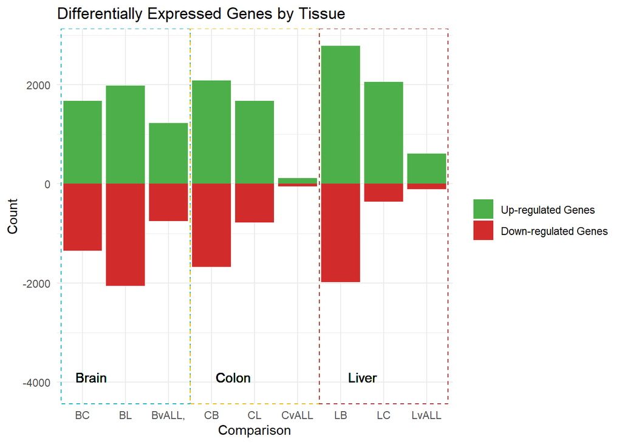

```r
p<-ggplot(updown, aes(x = category, y = up, fill = "Up-regulated")) +
    geom_bar(stat = "identity") +
    geom_bar(aes(y = down, fill = "Down-regulated"), stat = "identity") +
    scale_fill_manual(
        values = c("Up-regulated" = "#4DAF4A", "Down-regulated" = "#D22B2B"),
        breaks = c("Up-regulated", "Down-regulated"),
        labels = c("Up-regulated Genes", "Down-regulated Genes"),
        guide = guide_legend(label.sep = " | ")
    ) +
    labs(x = "Comparison", y = "Count", fill = NULL) +
    ggtitle("Differentially Expressed Genes by Tissue") +
    theme_minimal() +
    geom_rect(
        aes(xmin = 0.5, xmax = 3.5, ymin = -Inf, ymax = Inf),
        fill = NA, color = "#00AFBB", linetype = "dashed"
    ) +
    geom_rect(
        aes(xmin = 3.5, xmax = 6.5, ymin = -Inf, ymax = Inf),
        fill = NA, color = "#E7B800", linetype = "dashed"
    ) +
    geom_rect(
        aes(xmin = 6.5, xmax = 9.5, ymin = -Inf, ymax = Inf),
        fill = NA, color = "brown", linetype = "dashed"
    ) +
    geom_text(
        aes(x = 1.2, y = -4100, label = "Brain"), vjust = -0.5
    ) +
    geom_text(
        aes(x = 4.5, y = -4100, label = "Colon"), vjust = -0.5
    ) +
    geom_text(
        aes(x = 7.5, y = -4100, label = "Liver"), vjust = -0.5
    )
p
```

```r
# filterCB
# filterLB
# filterLC

topGenes <- list(
  BvALL = filterCB[intersect(rownames(filterCB)[filterCB$logFC > 0],
                             rownames(filterLB)[filterLB$logFC > 0]), ],

  CvALL = filterLC[intersect(rownames(filterCB)[filterLC$logFC > 0],
                             rownames(filterLC)[filterCB$logFC < 0]), ],

  LvALL = filterLC[intersect(rownames(filterLB)[filterLC$logFC < 0],
                             rownames(filterLC)[filterLB$logFC < 0]), ]
)

# Ordering by logFC
topGenes$BvALL <- topGenes$BvALL[order(topGenes$BvALL$logFC,
                                       decreasing = TRUE), ]
topGenes$CvALL <- topGenes$CvALL[order(topGenes$CvALL$logFC,
                                       decreasing = TRUE), ]
topGenes$LvALL <- topGenes$LvALL[order(topGenes$LvALL$logFC,
                                       decreasing = FALSE), ]
```

```r
head(topGenes$BvALL, n=10)
```

```
##             logFC    logCPM         F       PValue          FDR
## PIGR     15.85869 10.279964 187.28004 2.251497e-07 0.0001770929
## ZG16     14.59948  7.017637 102.45348 2.990983e-06 0.0003875436
## GGT6     14.09827  4.640562 108.22990 1.503006e-05 0.0007496478
## UGT2A3   13.86322  5.018477  81.64257 3.836374e-05 0.0012018791
## MOGAT2   13.64964  5.899326  89.60090 2.821272e-05 0.0010239288
## IGHV4-59 13.38467  4.196600 128.98700 8.324969e-06 0.0005670731
## IGLV2-14 13.00553  5.627935 110.75642 2.152678e-06 0.0003718985
## IGLV3-1  12.92500  3.878332 178.33197 2.763121e-06 0.0003840540
## IGHA2    12.65431  9.561762 108.98390 2.304707e-06 0.0003738810
## IGHV1-2  12.53846  3.234341  88.51894 2.937149e-05 0.0010481000
```

COLON

PIGR intestine,colon, non- specific ZG16 intestine, non- specific GGT6 colon

UGT2A3  
MOGAT2  
IGHV4-59  
IGLV2-14  
IGLV3-1 IGHA2  
IGHV1-2

```r
head(topGenes$CvALL, n=10)
```

```
##             logFC    logCPM         F       PValue          FDR
## CHRNA4  10.560790 5.7226072  30.11870 3.724625e-04 7.830580e-03
## ITIH3    9.767404 9.8213287 246.61933 6.747716e-08 1.462475e-04
## HPN      9.591701 7.9243610 488.69026 3.241839e-09 3.864435e-05
## BBOX1    8.850296 4.0788412  47.84390 6.594528e-05 2.710045e-03
## CES5A    8.404368 0.7764949  41.35210 1.154779e-04 3.899587e-03
## SDS      8.364679 7.2170503 122.71616 1.392716e-06 4.812136e-04
## SLC6A13  8.120118 4.2239888  85.35764 6.414148e-06 7.723919e-04
## SYT12    7.916935 3.8326198  30.77334 3.447816e-04 7.438858e-03
## HAL      7.762018 6.8027040 104.36459 2.767001e-06 5.728859e-04
## HOGA1    7.686518 4.6629515 113.10384 1.969712e-06 5.236510e-04
```

LIVER:

ITIH3 tissue enrinched liver BBOX1

```r
head(topGenes$LvALL, n=10)
```

```
##             logFC     logCPM         F       PValue          FDR
## PPP1R1B -8.457609 7.62718119 172.93159 3.183907e-07 0.0002526805
## GNG13   -7.931107 0.02747611  47.48873 2.196255e-04 0.0056753200
## POU3F3  -7.565921 4.79468994  74.48583 5.184576e-05 0.0023770285
## ATP10B  -7.505737 5.76604840  31.25051 3.261771e-04 0.0071539916
## EDN3    -6.464911 2.78553480  89.11832 5.362078e-06 0.0007222447
## ITLN1   -6.378363 5.80968951  70.44043 1.412816e-05 0.0011641207
## FMN2    -5.717622 4.33316751  30.52664 3.549078e-04 0.0075819727
## PRR15L  -4.117673 4.56215054  67.86215 1.644037e-05 0.0012562655
## BMP7    -3.774388 4.70896540  57.90407 3.111951e-05 0.0017929130
## PLCD3   -3.564940 6.04878288  44.29843 8.878327e-05 0.0032715332
```

BRAIN:

# Assigning TPM

```r
assays(rse_brain)$TPM <- recount::getTPM(rse_brain)
assays(rse_colon)$TPM <- recount::getTPM(rse_colon)
assays(rse_liver)$TPM <- recount::getTPM(rse_liver)
```

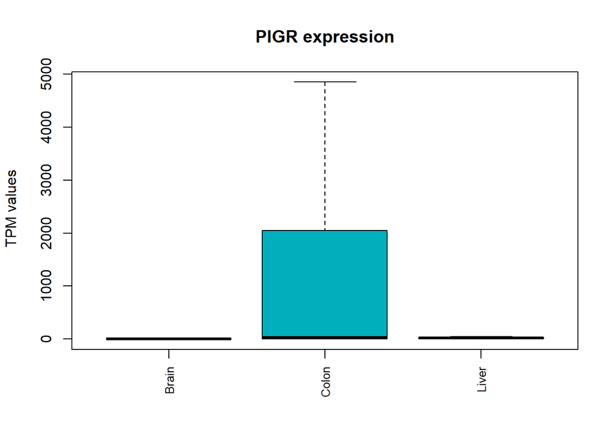

```r
PIGR <- which(rowData(rse_brain)$gene_name == "PIGR")

boxplot(assays(rse_brain)$TPM[PIGR,], assays(rse_colon)$TPM[PIGR,], assays(rse_liver)$TPM[PIGR,], outline=F, main = 'PIGR expression', ylab=' TPM values', xaxt = "n", names=c('Brain', 'Colon','Liver'), col = "#00AFBB")
axis(1, at = 1:3, labels = c('Brain', 'Colon','Liver'), las = 2, cex.axis = 0.8)
```

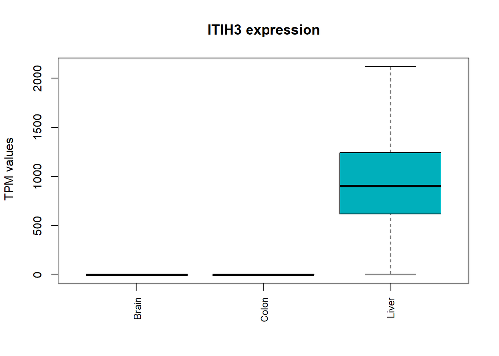

```r
ITIH3 <- which(rowData(rse_brain)$gene_name == "ITIH3")

boxplot(assays(rse_brain)$TPM[ITIH3,], assays(rse_colon)$TPM[ITIH3,], assays(rse_liver)$TPM[ITIH3,], outline=F, main = 'ITIH3 expression', ylab=' TPM values', xaxt = "n", names=c('Brain', 'Colon','Liver'), col = "#00AFBB")
axis(1, at = 1:3, labels = c('Brain', 'Colon','Liver'), las = 2, cex.axis = 0.8)
```

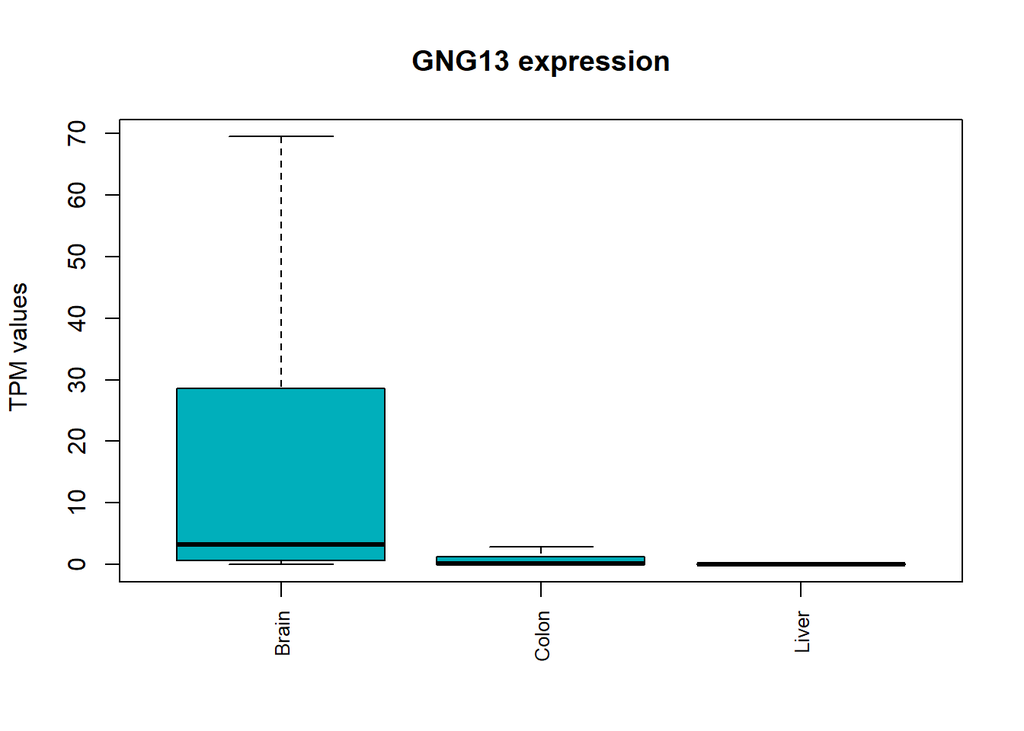

```r
GNG13 <- which(rowData(rse_brain)$gene_name == "GNG13")

boxplot(assays(rse_brain)$TPM[GNG13,], assays(rse_colon)$TPM[GNG13,], assays(rse_liver)$TPM[GNG13,], outline=F, main = 'GNG13 expression', ylab=' TPM values', xaxt = "n", names=c('Brain', 'Colon','Liver'), col = "#00AFBB")
axis(1, at = 1:3, labels = c('Brain', 'Colon','Liver'), las = 2, cex.axis = 0.8)
```